# Homework: numerical linear algebra and stability issues

# Problem 1: Kriging / Gaussian process regression

## Part 1: Finishing unfinished business from lecture

Execute a command `git grep -n "sq_exp_cov <- function"` from the root directory of the git repository. Paste the output below.

```bash
# Paste the `git grep` output.
homework/numerical_stability.Rmd:23:Execute a command `git grep -n "sq_exp_cov <- function"` from the root directory of the git repository.
lecture/finite_prec_and_numerical_stability.Rmd:276:sq_exp_cov <- function(dist, range) {
lecture/finite_prec_and_numerical_stability.Rmd:303:sq_exp_cov <- function(dist, range) {
```

The grep output tells you where you can find the (failed) kriging / Gaussian process regression example in the lecture source file. Copy the synthetic observation from there (the one defined on the range $[0, 0.4]$ and $[0.6, 1.0]$).

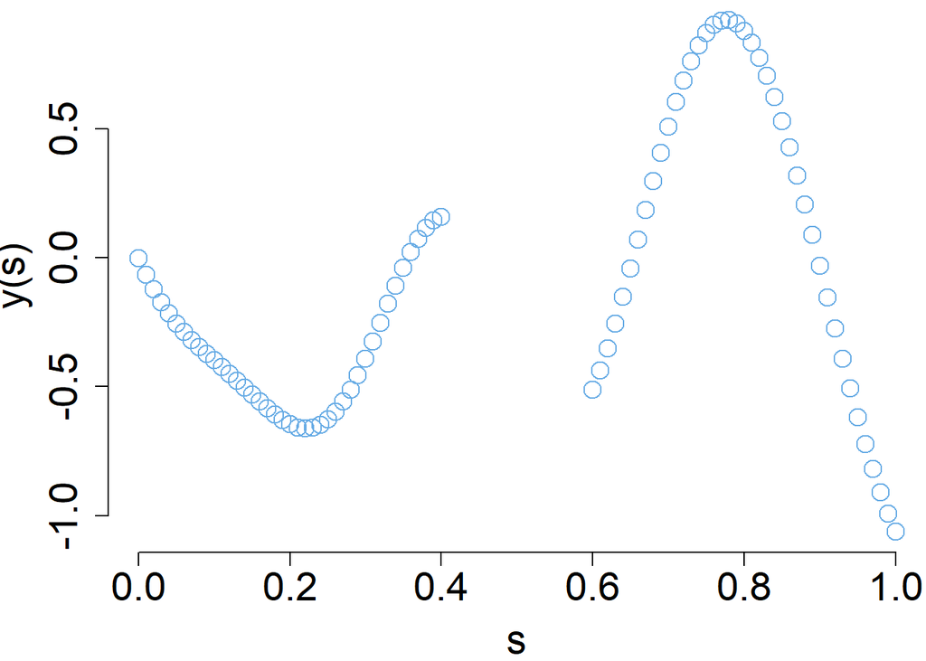

```r
# Fill in
sq_exp_cov <- function(dist, range) {
  return(exp(-(dist / range)^2))
}

loc_obs <- c(seq(0, .4, .01), seq(.6, 1, .01))
n_obs <- length(loc_obs)

set.seed(2021)
corr_range <- .2
dist_obs <- as.matrix(dist(loc_obs))
Sigma_obs <- sq_exp_cov(dist_obs, corr_range)
y_obs <- mvrnorm(mu = rep(0, n_obs), Sigma = Sigma_obs)
par(mar = c(4.1, 4.1, 0, 0))
plot(loc_obs, y_obs, xlab="s", ylab="y(s)",
     cex=1.8, cex.lab=1.8, cex.axis=1.8,
     col=jhu_color$spiritBlue, frame.plot = F)
```

Let’s now interpolate the missing values in $(0.4, 0.6)$ for real. To this end, we use eigen decomposition / pricipal component analysis of the GP. We can ignore the components with negligible ($\approx 0$) variance in computing $\boldsymbol{\Sigma}_{\textrm{obs}}^{-1} \boldsymbol{y}_{\textrm{obs}}$ since those components will not affect the final results of kriging/interpolation. In other words, we approximate $\boldsymbol{\Sigma}_{\textrm{obs}}^{-1}$ with $\sum_{i = 1}^k \lambda_i^{-1} \boldsymbol{u}_i \boldsymbol{u}_i^\intercal$ in computing $\boldsymbol{\Sigma}_{\textrm{obs}}^{-1} \boldsymbol{y}_{\textrm{obs}}$ for a suitably chosen number of principal components $k$. Choose $k$ to capture $99.99$% of variance in $\boldsymbol{y}_{\textrm{obs}} \sim \mathcal{N}(\boldsymbol{0}, \boldsymbol{\Sigma}_{\textrm{obs}})$.

The conditional mean $E(y_1 | y_2 = a) = \mu_1 + \Sigma_{12}\Sigma_{22}^{-1} (a- \mu_2)$.

```r
loc_new <- seq(.41, .59, .01)
# Compute the conditional mean of GP on the new locations.
gauss_conditional_mean_eigen_decomp <- function(y_2, mu_1, mu_2, cov_12, cov_22) {
  eigen_decomp = eigen(cov_22)
  eigen_vec = eigen_decomp$vectors
  eigen_val <- eigen_decomp$values
  eigen_val[which(abs(eigen_val)<1e-10)] = 0
  var_prop = cumsum(eigen_val)/sum(eigen_val)
  k = which(var_prop>0.9999)[1]
  cov_22_inv_approx = lapply(1:k,function(i){
    lambda_i_inv = ifelse(eigen_val[i]==0,0,eigen_val[i]^(-1))
    lambda_i_inv * eigen_vec[,i] %*% t(eigen_vec[,i])
  })
  cov_22_inv_approx = Reduce('+',cov_22_inv_approx)
  return(mu_1 + cov_12 %*% cov_22_inv_approx %*% (y_2 - mu_2))
}
loc_new <- seq(.41, .59, .01)
n_new <- length(loc_new)

dist_new <- as.matrix(dist(loc_new))
Sigma_new <- sq_exp_cov(dist_new, corr_range)
cross_dist <- as.matrix(dist(c(loc_new, loc_obs)))
cross_dist <- cross_dist[1:n_new, (n_new + 1):(n_new + n_obs)]
Sigma_cross <- sq_exp_cov(cross_dist, corr_range)
mean_obs <- rep(0, n_obs)
mean_new <- rep(0, n_new)
y_predicted <- gauss_conditional_mean_eigen_decomp(y_obs, mean_new, mean_obs, Sigma_cross, Sigma_obs)
```

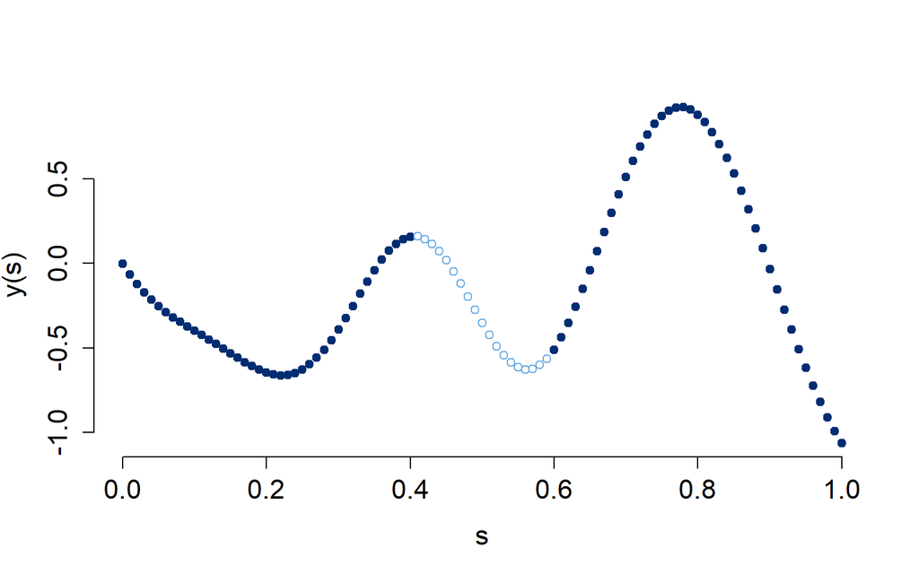

```r
solid_circle_index <- 19
plot(
  # Fill in
  loc_obs, y_obs,
  xlab="s", ylab="y(s)",
  pch=solid_circle_index,
  cex.lab=1.4, cex.axis=1.4,
  col=jhu_color$heritageBlue,
  frame.plot = F
)
points(
  # Fil in
  loc_new,y_predicted,
  col = jhu_color$spiritBlue
)
```

## Part 2: Quantifying uncertainty in interpolation

Use the eigen-decomposition technique to compute the conditional covariance
$$\textrm{Var}(\boldsymbol{y}_1 \, | \, \boldsymbol{y}_2)
= \boldsymbol{\Sigma}_{11} - \boldsymbol{\Sigma}_{12} \boldsymbol{\Sigma}_{22}^{-1} \boldsymbol{\Sigma}_{21},$$
calculate 95% CI intervals of the interpolation, and plot them.

We calculate CI for each single new point $y_i (i= 1,2,...,n_{new})$ given observations $y_{obs}$, $Var(y_i | y_{obs}) = \Sigma_{11}^{(ii)}- \Sigma_{12}^{(i \cdot)} \Sigma_{22}^{-1} \Sigma_{21}^{(\cdot i)}$, where $A^{(ij)}$ represents the $(i,j)$-th entry of matrix $A$. Then the 95% CI could be derived as $(E(y_i |y_{obs}) - 1.96 \sqrt{Var(y_i | y_{obs})},E(y_i |y_{obs}) + 1.96 \sqrt{Var(y_i | y_{obs})})$.

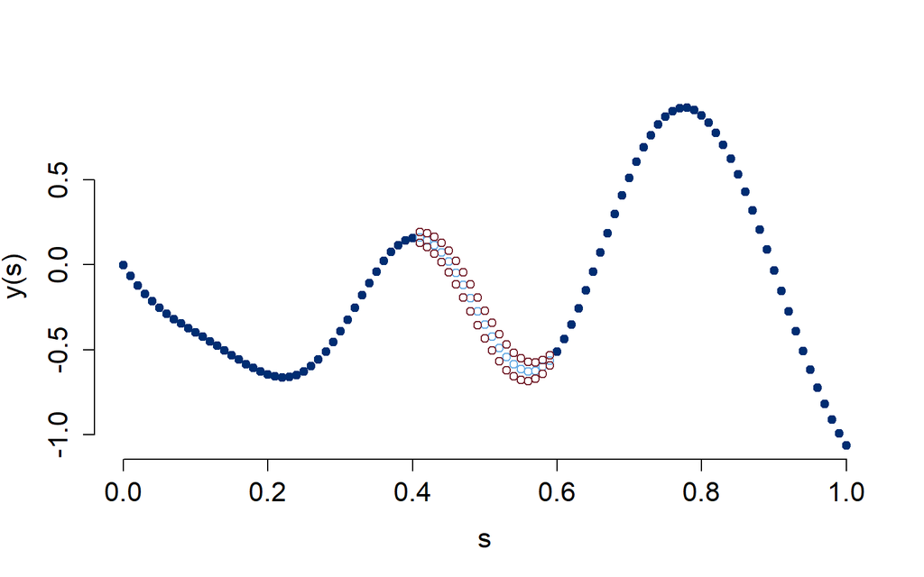

```r
gauss_conditional_cov_eigen_decomp <- function(cov_11,cov_12, cov_22) {
  eigen_decomp = eigen(cov_22)
  eigen_vec = eigen_decomp$vectors
  eigen_val <- eigen_decomp$values
  eigen_val[which(abs(eigen_val)<1e-10)] = 0
  var_prop = cumsum(eigen_val)/sum(eigen_val)
  k = which(var_prop>0.9999)[1]
  cov_22_inv_approx = lapply(1:k,function(i){
    lambda_i_inv = ifelse(eigen_val[i]==0,0,eigen_val[i]^(-1))
    lambda_i_inv * eigen_vec[,i] %*% t(eigen_vec[,i])
  })
  cov_22_inv_approx = Reduce('+',cov_22_inv_approx)
  return(cov_11 - cov_12 %*% cov_22_inv_approx %*% t(cov_12))
}
## variance at a single new point
var_predicted = sapply(1:length(loc_new),function(i){
  gauss_conditional_cov_eigen_decomp(Sigma_new[i,i],matrix(Sigma_cross[i,],nrow = 1), Sigma_obs)
})
CI_predicted = cbind(y_predicted-qnorm(0.975)*sqrt(var_predicted),y_predicted+qnorm(0.975)*sqrt(var_predicted))
colnames(CI_predicted)= c("Lower","Upper")


solid_circle_index <- 19
plot(
  # Fill in
  loc_obs, y_obs,
  xlab="s", ylab="y(s)",
  pch=solid_circle_index,
  cex.lab=1.4, cex.axis=1.4,
  col=jhu_color$heritageBlue,
  frame.plot = F
)
points(
  # Fil in
  loc_new,y_predicted,
  col = jhu_color$spiritBlue
)
points(
  # Fil in
  loc_new,CI_predicted[,1],
  col = jhu_color$maroon
)
points(
  # Fil in
  loc_new,CI_predicted[,2],
  col = jhu_color$maroon
)
```

## Part 3: Kriging based on an alternative GP covariance function

Albeit popular in certain fields, GP based on squared exponential covariance function is often considered “too smooth” for many applications. In particular, its smoothness is partially responsible for the extreme ill-conditioning of its covariance matrix. Here we try carrying out the same interpolation task instead using a *Matern* covariance function.

First find the definition and implementation of a Matern covariance using a command `git grep -n "Matern"`.

```bash
homework/numerical_stability.Rmd:75:Here we try carrying out the same interpolation task instead using a _Matern_ covariance function.
homework/numerical_stability.Rmd:77:First find the definition and implementation of a Matern covariance using a command `git grep -n "Matern"`.
lecture/finite_prec_and_numerical_stability.Rmd:255:<!-- Matern covariance with smoothness $\nu = 5/2$: -->
lecture/iterative_method_brief_tour.Rmd:197:<img src="figure/inla_gmrf_approximatin.png" alt="Markovian approximation of Matern field" class="center" style="width: 80%;"/>
```

```r
# Definition of the `matern_cov` function.
# nu = 5/2
 matern_cov <- function(dist, range) {
   scaled_dist <- dist / range
   return(
   (1 + sqrt(5) * scaled_dist + 5 / 3 * scaled_dist^2)
     * exp(- sqrt(5) * scaled_dist)
  )
}
```

Then use the eigen decomposition technique as before for interpolation and uncertainty quantification. Afterward, check the condition number of $\boldsymbol{\Sigma}_{\textrm{obs}}$ and see if you can directly compute $\boldsymbol{\Sigma}_{\textrm{obs}}^{-1} \boldsymbol{y}_{\textrm{obs}}$ using the `solve` function. Do we get the same answer as the one based on eigen decomposition?

We derive similar predicted values and CI, but not exactly the same. Because we approximate the $\Sigma_{obs}^{-1}$ using first $k$ components.

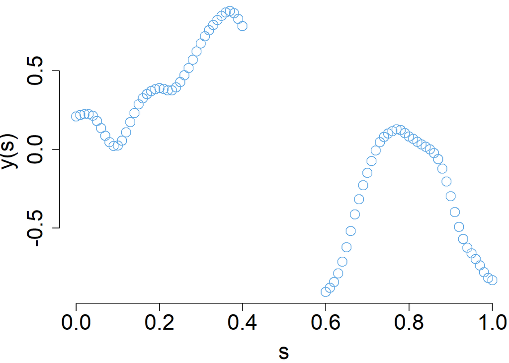

```r
# Fill in
## observation
loc_obs <- c(seq(0, .4, .01), seq(.6, 1, .01))
n_obs <- length(loc_obs)

set.seed(2021)
scale_range <- .2
dist_obs <- as.matrix(dist(loc_obs))
Sigma_obs <- matern_cov(dist_obs, scale_range)
y_obs <- mvrnorm(mu = rep(0, n_obs), Sigma = Sigma_obs)

par(mar = c(4.1, 4.1, 0, 0))
plot(loc_obs, y_obs, xlab="s", ylab="y(s)",
     cex=1.8, cex.lab=1.8, cex.axis=1.8,
     col=jhu_color$spiritBlue, frame.plot = F)
```

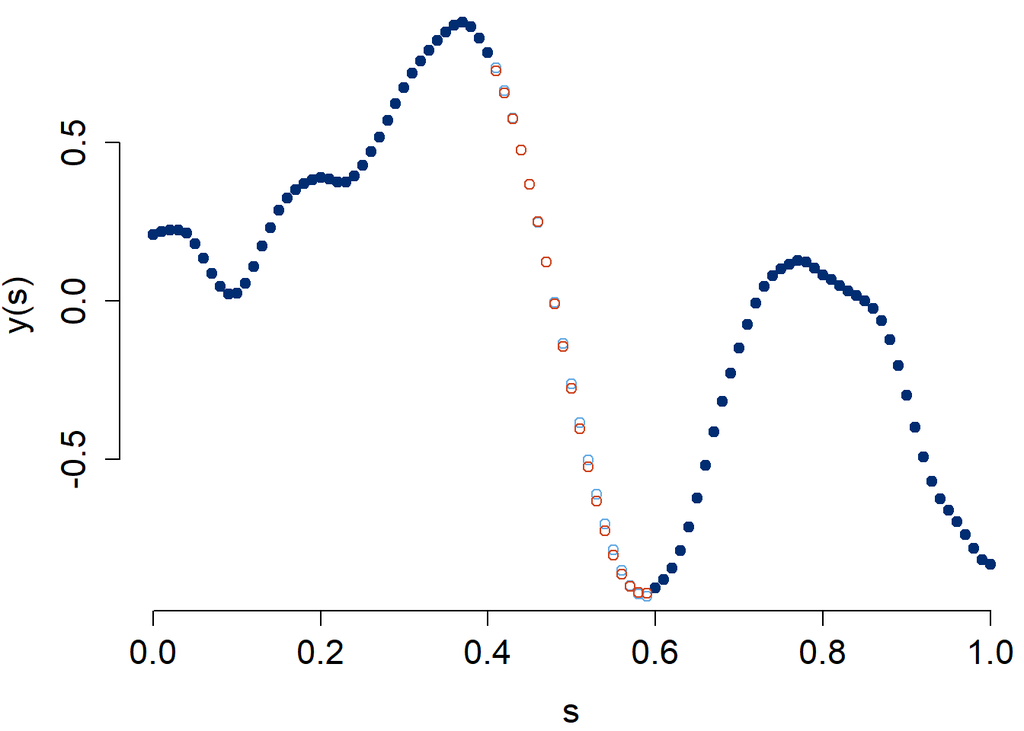

```r
## interpolation
loc_new <- seq(.41, .59, .01)
n_new <- length(loc_new)

dist_new <- as.matrix(dist(loc_new))
Sigma_new <- matern_cov(dist_new, scale_range)
cross_dist <- as.matrix(dist(c(loc_new, loc_obs)))
cross_dist <- cross_dist[1:n_new, (n_new + 1):(n_new + n_obs)]
Sigma_cross <-  matern_cov(cross_dist, scale_range)
mean_obs <- rep(0, n_obs)
mean_new <- rep(0, n_new)
## eigen_decomp
y_predicted <- gauss_conditional_mean_eigen_decomp(y_obs, mean_new, mean_obs, Sigma_cross, Sigma_obs)

## solve
gauss_conditional_mean <- function(y_2, mu_1, mu_2, cov_12, cov_22) {
  return(mu_1 + cov_12 %*% solve(cov_22, y_2 - mu_2))
}
y_predicted_solve <- try(gauss_conditional_mean(y_obs, mean_new, mean_obs, Sigma_cross, Sigma_obs))

## interpolation plot
solid_circle_index <- 19
plot(
  # Fill in
  loc_obs, y_obs,
  xlab="s", ylab="y(s)",
  pch=solid_circle_index,
  cex.lab=1.4, cex.axis=1.4,
  col=jhu_color$heritageBlue,
  frame.plot = F
)
points(
  # Fil in
  loc_new,y_predicted,
  col = jhu_color$spiritBlue
)
points(
  # Fil in
  loc_new,y_predicted_solve,
  pch = 1,
  col = jhu_color$orange
)
```

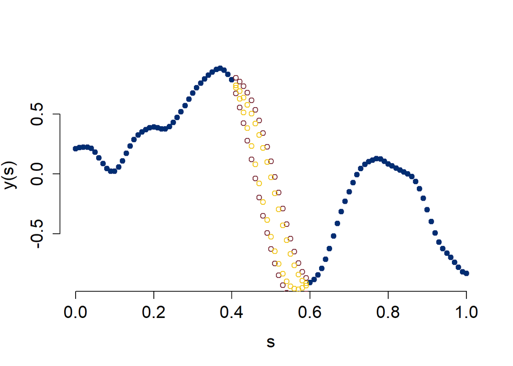

```r
# uncertainty quantification.
var_predicted = sapply(1:length(loc_new),function(i){
  gauss_conditional_cov_eigen_decomp(Sigma_new[i,i],matrix(Sigma_cross[i,],nrow = 1), Sigma_obs)
})
CI_predicted = cbind(y_predicted-qnorm(0.975)*sqrt(var_predicted),y_predicted+qnorm(0.975)*sqrt(var_predicted))
colnames(CI_predicted)= c("Lower","Upper")

gauss_conditional_cov_solve <- function(cov_11,cov_12, cov_22) {
  return(cov_11 - cov_12 %*% solve(cov_22,t(cov_12)))
}
var_predicted_solve = sapply(1:length(loc_new),function(i){
  gauss_conditional_cov_solve(Sigma_new[i,i],matrix(Sigma_cross[i,],nrow = 1), Sigma_obs)
})
CI_predicted_solve = cbind(y_predicted_solve-qnorm(0.975)*sqrt(var_predicted_solve),y_predicted_solve+qnorm(0.975)*sqrt(var_predicted_solve))
colnames(CI_predicted_solve)= c("Lower","Upper")



solid_circle_index <- 19
plot(
  # Fill in
  loc_obs, y_obs,
  xlab="s", ylab="y(s)",
  pch=solid_circle_index,
  cex.lab=1.4, cex.axis=1.4,
  col=jhu_color$heritageBlue,
  frame.plot = F
)
points(
  # Fil in
  loc_new,CI_predicted[,1],
  col = jhu_color$maroon
)
points(
  # Fil in
  loc_new,CI_predicted[,2],
  col = jhu_color$maroon
)
points(
  # Fil in
  loc_new,CI_predicted_solve[,1],
  col = jhu_color$yellow
)
points(
  # Fil in
  loc_new,CI_predicted_solve[,2],
  col = jhu_color$yellow
)
```

**Bonus question:** Symmetric positive-definite matrices can be inverted more quickly via the *Cholesky decomposition* $\boldsymbol{L} \boldsymbol{L}^\intercal = \boldsymbol{A}$ than via the LU or QR decomposition. The Cholesky decomposition also provides the “sqrt” of covariance matrix you need to sample from multivariate Gaussians. (Though you might be stuck with the eigen decomposition technique if the matrix is ill-conditioned.) Try computing $\boldsymbol{\Sigma}_{\textrm{obs}}^{-1} \boldsymbol{y}_{\textrm{obs}}$ via `chol` and `forward/backsolve`.

Our goal is to solve $\boldsymbol{\Sigma}_{\textrm{obs}} x = \boldsymbol{y}_{\textrm{obs}}$, we plug in the Cholesky decompostion of the observed covariance matrix: $\boldsymbol{\Sigma}_{\textrm{obs}} = \boldsymbol{L} \boldsymbol{L}^\intercal$ and derive $\boldsymbol{L} \boldsymbol{L}^\intercal x = \boldsymbol{y}_{\textrm{obs}}$. The first step is to solve $\boldsymbol{L}^\intercal x$ using `forwardsolve` function $\texttt{forwardsolve}(\boldsymbol{L}, \boldsymbol{y}_{\textrm{obs}})$. Then the second step is to solve $x$ using `backsolve` function $\texttt{backsolve}(\boldsymbol{L}^\intercal, \boldsymbol{L}^\intercal x)$. We further verify that Cholesky decomposition and `solve` function give the same answer.

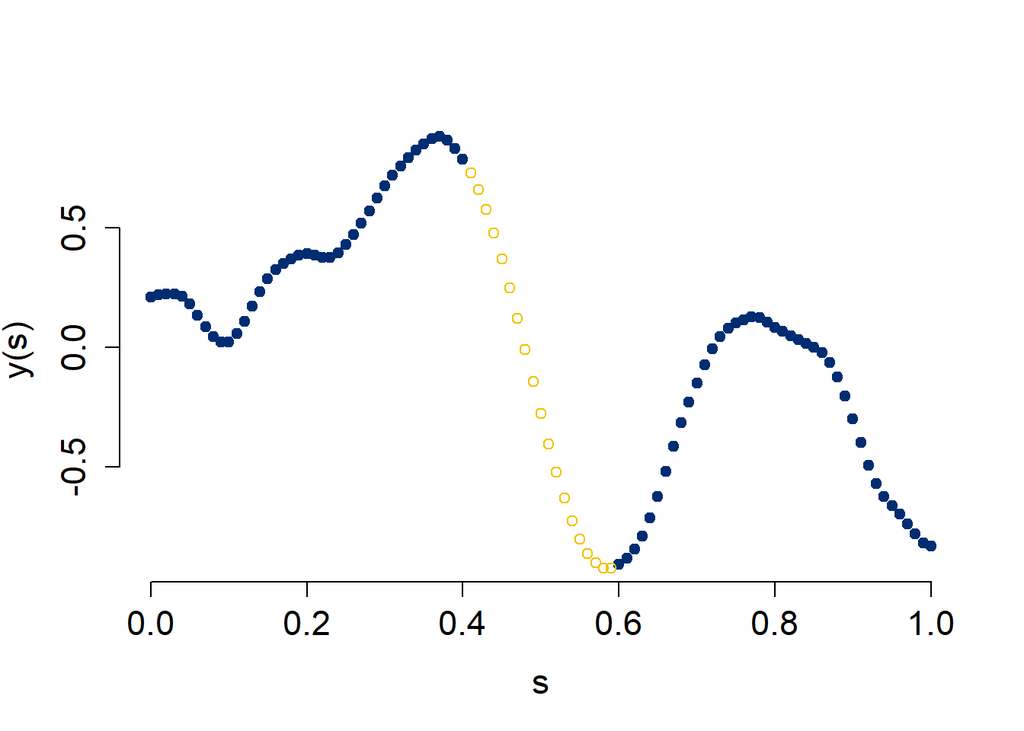

```r
gauss_conditional_mean_chol <- function(y_2, mu_1, mu_2, cov_12, cov_22) {
  L = t(chol(cov_22))
  Lstar_x = forwardsolve(L,y_2 - mu_2)
  x = backsolve(t(L),Lstar_x)
  return(mu_1 + cov_12 %*% x)
}
y_predicted_chol = gauss_conditional_mean_chol(y_obs, mean_new, mean_obs, Sigma_cross, Sigma_obs)

are_all_close <- function(vector1, vector2, rel_tol = 1e-3) {
  ave_magnitude <- (abs(vector1) + abs(vector2)) / 2
  coord_rel_err <- abs(vector1 - vector2) / ave_magnitude
  return(all(coord_rel_err < rel_tol, na.rm = T))
}
assert("Chelosky decomposition results are consistent with the solve results", {
  are_all_close(y_predicted_chol, y_predicted_solve)
})

solid_circle_index <- 19
plot(
  # Fill in
  loc_obs, y_obs,
  xlab="s", ylab="y(s)",
  pch=solid_circle_index,
  cex.lab=1.4, cex.axis=1.4,
  col=jhu_color$heritageBlue,
  frame.plot = F
)
points(
  # Fil in
  loc_new,y_predicted_solve,
  col = jhu_color$maroon
)
points(
  # Fil in
  loc_new,y_predicted_chol,
  col = jhu_color$yellow
)
```